# basic_stats slides

```python
import numpy as np
import pandas as pd
import scipy.stats
import matplotlib.pyplot as plt
```

### $\chi^2$ goodness-of-fit test

- The $\chi^2$ goodness-of-fit test is one of the oldest hypothesis tests around
- A Chi-square test is a hypothesis testing method
  - Two different flavors
  - The goodness of fit Chi-square tests involve checking if observed frequencies in one or more categories match expected frequencies
- Cateorical data refers to data with a "nominal scale"
  - A scale of measurement used to assign events or objects into discrete categories

### The Card Radnomness Test

- Ask 200 people to mentally choose two card suits. Is the choice random?
- Suppose the data is:

```
clubs diamonds   hearts   spades
      35       51       64       50
```

### How do we Reprodcude Similar Data?

- The Observed frequncies $O = (O_1, O_2, O_3, O_4) = (35,51,64,50)$
- How do we sample similar data in Python ?
  - Ex. How can you randomly sample 200 opbserations of 4 events?
- Which distribution should we use?
  - Recall, this is simply a generalization of (coin flip)

```python
n = 1
size = 200
prob = [1/4, 1/4, 1/4, 1/4]
np.random.multinomial(200, prob)
```

```
array([55, 41, 61, 43])
```

### Pearson’s $\chi^2$ goodness of fit test

- Our assumtpion is that the card (categories, or whatever other counts) are not uniformly represented.
  - $H_0$: All four suits are chosen with equal probability
  - $H_A$: At least one of the suit-choice probabilities isn’t 0.25
- How to test this hypothesis?
- Same as the test we had manually run
  - Sample uniformly represented card
  - Compute some test statistics
  - Plot where the observed statistics occurs under the null distribution
- This is exactly what the $\chi^2$ goodness of fit tests
  - $H_0$: $P = (25,.25,.25,.25)$
  - $H_A$: $P \ne (.25,.25,.25,.25)$

### The “Goodness of Fit” Test Statistic

- Similar to what we've done via simulation, if we want to test $H_0$ against $H_1$, we’re going to need a test statistic
  - Measures how “close” the data are to the null hypothesis
  - If the data don’t resemble what you would “expect” to see if the null hypothesis were true, then it probably isn’t true
  - What are the expected frequencies?

```python
### What is this called in R?
probabilities = {"clubs": .25, "diamonds": .25, "hearts": .25, "spades": .25}
probabilities
```

```
{'clubs': 0.25, 'diamonds': 0.25, 'hearts': 0.25, 'spades': 0.25}
```

```python
probabilities = pd.Series([0.25,0.25,0.25,0.25], index=["clubs", "diamonds","hearts", "spades"])
```

```python
expected= 200 * probabilities
expected
```

```
clubs       50.0
diamonds    50.0
hearts      50.0
spades      50.0
dtype: float64
```

### Compare Expected versus Observed

Objetive: compare the expected (Ei) wiht observed vals in each category

[figure not shown]

- Sign should not matter + 14 hearts and -15 clubs should be equivalent to -14 hearts and +15 clubs
  - Easy: we can just count the squared error
- We' also interested in contextualizing that error.
  - +14 with regards to what
  - Let's divide by the expectation so we can also represent this error in terms of units representing how far form the expectation it is.
  - The total distance we're off by is the sum of all of these.

```python
observed = pd.Series([35, 51, 64, 50], index=["clubs", "diamonds","hearts", "spades"])
observed - expected
```

```
clubs      -15.0
diamonds     1.0
hearts      14.0
spades       0.0
dtype: float64
```

```python
(observed - expected)**2 / expected
```

```
clubs       4.50
diamonds    0.02
hearts      3.92
spades      0.00
dtype: float64
```

```python
(observed - expected)**2 / expected
```

```
clubs       4.50
diamonds    0.02
hearts      3.92
spades      0.00
dtype: float64
```

```python
sum((observed - expected)**2 / expected)
```

```
8.44
```

### The $\chi^2$ Statistic

- What we Computed Above is the $\chi^2$ Statistic

$$ \chi^2 = \sum_{i=1}^{k} \frac{(E_i - O_i)^2}{E_i} $$

where $k$ is the number of categories

- Similar to our similations with the SVD distance, it's easy to observe that large vlaue of $\chi^2$ are in favor of the alternaitves, i.e.:
- If $\chi^2$ is small, then $O_i$ and $E_i$ are close (Null hypothesis is okay)
- If $\chi^2$ is large, then Oi cannot come from the same distribution as Ei (the uniform here)
- Is $\chi^2 = 8.44$ large or small?
- Note that the chi-squared goodness of fit test is always a one-sided test

### The sampling distribution of the GOF Statistic

- What should $\chi^2$ values look like if we sample randomly form the uniform.
  - i.e., what does the sampling distribution of $\chi^2$ looks like
- Recall, that essentially, $O_i$, observed frequency for a category $i$ is distributed according to a binomial $$ O_i \sim \text{Binomial}(P_i, N) $$
- For large values of $N$ and when $P_i$ isn’t too close to 0 or 1, the Central Limit Theorem say that the the binomial is similar to the Gaussian

```python
N = 200
p = 0.4
```

```python
np.random.binomial(N, p)
```

```
83
```

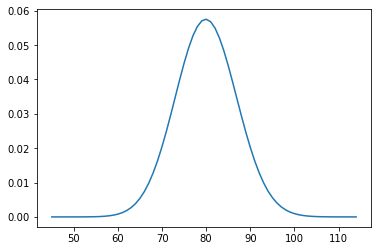

```python
x_axis = np.arange(45, 115)
y_axis = scipy.stats.binom.pmf(x_axis, N, p)

plt.plot(x_axis, y_axis)
```

# From the Guassian to the $\chi^2$

- According to a central limit theorem, when $E_i = N \times P_i$ is large, then $O_i$ follows a Gaussian
- If $O_i$ is normally distributed, then so is $(O_i - E_I) / \sqrt{E_i}$
  - This represents one of the terms of the statistic (minus the square)
- The test consists of a sum of $k$ terms $(O_i - E_I) / \sqrt{E_i}$
- Square and adding a collection of normally distributed variables yields a quantity that has a chi-square distribution
  - Then $\chi^2$ distribution appears everywhere
  - Recall the sum of residuals discussed last week?
- The parameter of a $\chi^2$ is it's degrees of freedom

```python
scipy.stats.chi2(df=10).rvs()
```

```
7.705584091917882
```

```python
scipy.stats.chi2(df=100).rvs(4)
```

```
array([98.1964695 , 83.86969639, 88.48042699, 97.01002497])
```

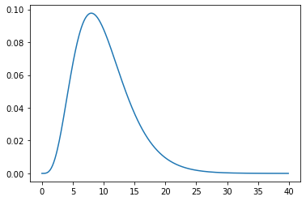

```python
x_axis = np.arange(0, 40, 0.1)
y_axis = scipy.stats.chi2(df=10).pdf(x_axis)

plt.plot(x_axis, y_axis)
```

### Degrees of Freedon of the $\chi^2$

- Square and adding a collection of normally distributed variables yields a quantity that has a chi-square distribution
- We are interested in the number of independent "things" we're adding up.
  - Here, only $k-1$ categories are independent
  - Since the values sum to one, then with $k-1$ categories we can infer the value of the last category
  - So the degree os freedom is $k-1$
- The above is an oversimplification
  - “degrees of freedom” is actually a bit of a messy concept
  - degrees of freedom may not even be a whole number

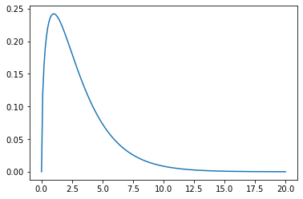

```python
x_axis = np.arange(0, 20.1, 0.1)
y_axis = scipy.stats.chi2(df=3).pdf(x_axis)

plt.plot(x_axis, y_axis)
```

```python
chi2_rv = scipy.stats.chi2(df=3)
### The cdf refers to the cumulative distribution function
### The cumulative distribution function (cdf) is the probability that the variable takes a value less than or equal to x.

chi2_rv.cdf(0)
```

```
0.0
```

```python
chi2_rv.cdf(20)
```

```
0.9998302575644472
```

```python
print(x_axis[:10])
print(x_axis[-10:])
```

```
[0.  0.1 0.2 0.3 0.4 0.5 0.6 0.7 0.8 0.9]
[19.1 19.2 19.3 19.4 19.5 19.6 19.7 19.8 19.9 20. ]
```

```python
probs = chi2_rv.cdf(x_axis)
print(np.round(probs[:10], decimals=4))
print(np.round(probs[-10:], decimals=4))
```

```
[0.     0.0082 0.0224 0.04   0.0598 0.0811 0.1036 0.1268 0.1505 0.1746]
[0.9997 0.9998 0.9998 0.9998 0.9998 0.9998 0.9998 0.9998 0.9998 0.9998]
```

```python
np.where(probs > 0.95)
```

```
(array([ 79,  80,  81,  82,  83,  84,  85,  86,  87,  88,  89,  90,  91,
         92,  93,  94,  95,  96,  97,  98,  99, 100, 101, 102, 103, 104,
        105, 106, 107, 108, 109, 110, 111, 112, 113, 114, 115, 116, 117,
        118, 119, 120, 121, 122, 123, 124, 125, 126, 127, 128, 129, 130,
        131, 132, 133, 134, 135, 136, 137, 138, 139, 140, 141, 142, 143,
        144, 145, 146, 147, 148, 149, 150, 151, 152, 153, 154, 155, 156,
        157, 158, 159, 160, 161, 162, 163, 164, 165, 166, 167, 168, 169,
        170, 171, 172, 173, 174, 175, 176, 177, 178, 179, 180, 181, 182,
        183, 184, 185, 186, 187, 188, 189, 190, 191, 192, 193, 194, 195,
        196, 197, 198, 199, 200]),)
```

```python
index = np.where(probs > 0.95)[0][0]
index
```

```
79
```

```python
print(x_axis[index])
print(probs[index])
```

```
7.9
0.9518757481558399
```

```python
# ppf is the inverse of the cdf
chi2_rv.ppf(.95)
```

```
7.814727903251179
```

```python
# Give me the area under the upper tail instead
1 - chi2_rv.cdf(8.44)
```

```
0.03774185202402136
```

```python
observed
```

[output not shown]

```python
result = scipy.stats.chisquare(observed)
result
```

```
Power_divergenceResult(statistic=8.44, pvalue=0.0377418520240214)
```

```python
observed
```

```
clubs       35
diamonds    51
hearts      64
spades      50
dtype: int64
```

```python
result = scipy.stats.chisquare(f_obs=observed, f_exp=[40, 50, 60, 50])
result
```

```
Power_divergenceResult(statistic=0.9116666666666666, pvalue=0.8226115000538757)
```

### The $\chi^2$ test of independence (or association)

[figure not shown]

- Question: is the distribution of the datat the same across both sites?
  - Are the proprtions of `lives`, `dies`, or `unhealthy` the same across both sites

### Constructing our Hypothesis Test

[figure not shown]

- $O_{ij}$ is a count (observed frequency) of the number of respondents that are at a site (siteA or siteB) which lead to condition i (lives, dies, unhealth)
- The total number of observations is written N, as usual.
- $R_i$ to denote the row totals
- $C_j$ to denote the column totals

### Constructing the Hypothesis Test

- If both sites yield the same outcomes, then probability of dies is equal in both sites
  - by the same token, prob of healthy is also similar in both site
  - by the same token, prob of lives also similar in both site
- $H_0$: All of the following are true:
  - $P_{11}$ = $P_{12}$ (same probability of dies),
  - $P_{21}$ = $P_{22}$ (same probability of unhealthy).
  - $P_{31}$ = $P_{32}$ (same probability of lives).
- We denote `p_i`, where i in {1,2,3} as the prob of `dies`, `unhealthy` or `lives` respectively.

### Constructing the Hypothesis Test

- Unlike goodness of fit test, the null hypothesis doesn’t actually specify a particular value for P_i.
  - We can estimate it from the data
  - If 28 out of 180 spcies died, then the empirical probability is simply 28/180 ( .16)

$$ \hat{P}_i = \frac{R_i}{N} $$

Expected frequency is therefore: $$ \hat{E}_{ij} = \frac{R_i}{C_j}/N $$

### Defining the test statistic

- Following the exact same strategy that we used in the goodness of fit test.
  - Exact same statistic. For a contingency table with r rows and c columns, the equation that defines our $\chi^2$ statistic is:

$$ \chi^2 = \sum_{i=1}^{r}\sum_{j=1}^{c}\frac{(E_{ij}-O_{ij})^2}{E_ij} $$

- For the same reasons as above, this stat is also distributed accroding to the $\chi^2$ distribution
- How many independet pints are we analyzing
- Here, df = (r-1)(c-1)

### Effect Size

- As we discussed when we did similar test with simulation, it's common to report some measure of effect size.
  - Is there a significant effect or are we splitting hairs?
- Here several tests can be use. Two most common is Cramer’s V. $$ V = \sqrt{\frac{X^2}{N(k-1)}} $$

### Assumptions of the Test

- Expected frequencies are sufficiently large.
  - Expected frequencies larger than at least 5
    - Assumption needed to approximate the central limit theorem.
  - For larger tables, at least 80% of the the expected frequencies are above 5 and none is 0
- Data are independent of one another
  - Ex. the fact that a species dies, does not increase the change of another species dying.

### Test of Independence in R

- Also uses chisq.test() function Requires a cross-tabulation rather than a simple frequency table
  - Knows you'r asking for a test of independence and not a goodness of fit test

### The Fisher exact test

- A test of independence used with small data
  - Works somewhat differently to the chi-square test
  - doesn’t have a test statistic; calculates the p-value “directly”
- Uses the hypergeometric ditribution to compute the test
  - Same test usually used for assessing enrichment in genomics
  - Given that 20 genes out of 200 are in DNA replication but 10 genes out of the differentially expressed are in DNA replication. Question: is DNA replication enriched.

### McnNemar Test

- Used on 2x2 Contingency tables
  - Used with paired data
  - Example: on before after sort of experiment
- You measure agressiveness of sharks before and after adding a compound to the water and measure how many exhibited predatory behavior

[figure not shown]

- Can we use the chi-square to test the independence?

### McnNemar Test - Cont'd

- We can use the $\chi^2$ test of independence because the data is not independent
  - Each animal shows in the before and after columns
  - Before drug, Animal 1 shows agressiveness while 2 doesn't
  - After drug, Animal 1 has a higher likelihood of showing agressiveness than animal 2.

### McnNemar Test - Cont'd

- Requires re-writing the data to minimize the dependence

[figure not shown]

- Same data, but each of the 100 animals appears once in the table
  - Independence assumption is now satisfied since non of the animal appears twice
  - Still assuming that animal agressiveness is independent (no contagious)
- Requires computing the $X^2$ test statistic slighly differently
  - Adjust for table transformation

```python
load("data/animal_agression.Rdata")
head(agpp)
```

A data.frame: 6 × 3

|  | id <fct> | response_before <fct> | response_after <fct> |
| --- | --- | --- | --- |
| 1 | subj.1 | no | yes |
| 2 | subj.2 | yes | no |
| 3 | subj.3 | yes | no |
| 4 | subj.4 | yes | no |
| 5 | subj.5 | no | no |
| 6 | subj.6 | no | no |

```python
summary(agpp)
```

```
        id     response_before response_after
 subj.1  : 1   no :70          no :90
 subj.10 : 1   yes:30          yes:10
 subj.100: 1
 subj.11 : 1
 subj.12 : 1
 subj.13 : 1
 (Other) :94
```

```python
freq_table = xtabs( ~ response_before + response_after, data = agpp)
freq_table
```

```
               response_after
response_before no yes
            no  65   5
            yes 25   5
```

```python
mcnemar.test( freq_table)
```

```
	McNemar's Chi-squared test with continuity correction

data:  freq_table
McNemar's chi-squared = 12.033, df = 1, p-value = 0.0005226
```

### McnNemar Test

- Suppose I wanted to know whether the choice you make the second time is dependent on the choice you made the first time.
  - Test of independence
- Suppose I wanted to know if, on average, the frequencies of suit choices were different the second time than the first time.
  - That's a McNemar Test

```python
summary(cards)
```

```
       id          choice_1      choice_2
 subj1  :  1   clubs   :35   clubs   :68
 subj10 :  1   diamonds:51   diamonds:44
 subj100:  1   hearts  :64   hearts  :41
 subj101:  1   spades  :50   spades  :47
 subj102:  1
 subj103:  1
 (Other):194
```

```python
card_choices = xtabs( ~ choice_1 + choice_2, data = cards )
card_choices
```

```
          choice_2
choice_1   clubs diamonds hearts spades
  clubs       10        9     10      6
  diamonds    20        4     13     14
  hearts      20       18      3     23
  spades      18       13     15      4
```

```python
chisq.test( card_choices )
```

```
	Pearson's Chi-squared test

data:  card_choices
X-squared = 29.237, df = 9, p-value = 0.0005909
```

```python
mcnemar.test(card_choices)
```

```
	McNemar's Chi-squared test

data:  card_choices
McNemar's chi-squared = 16.033, df = 6, p-value = 0.01358
```

### T-test

- The t-test tells you whether the differences between groups is statistically significant.
  - I.e., could the difference have happened by chance?
- Approach very similar to what we covered uisng simulations
- Used for example to:
  - In a medical context, we might want to know if a new drug increases or decreases blood pressure.
  - Compare the average transaction value between two companies.